# Exploratory analysis

Carolina S. Marques

# 1 Introduction

In this document we obtain depth profiles (Figure 2 in the article) and basic information on the behavior of the narwhals, for example: proportion of time spent clicking; time until the resume of the regular echolocation clicks; total length of the recording; length of the recording used for the analysis…

# 2 Reading data

```r
#read data obtained in "01_data_processing.rmd":
load("originald_data_processed.rda")
load("processed_data.rda")
sampledata<-sampledata[sampledata$rsecs>=0&!is.na(sampledata$clicks),]
```

# 3 Depth profiles with all of the records

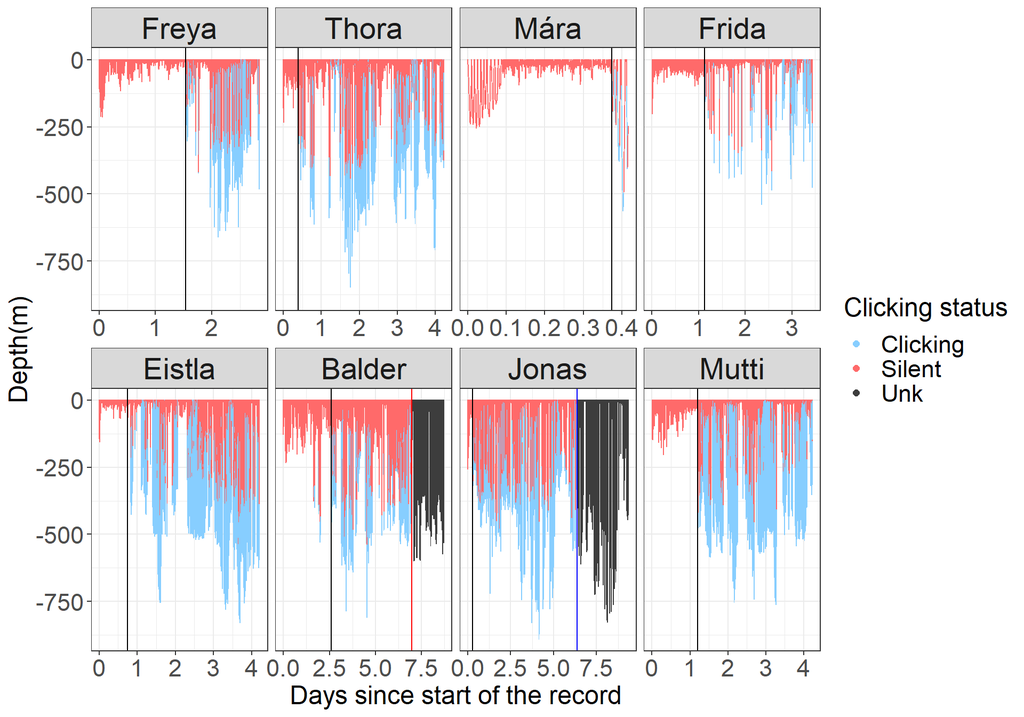

```r
datasec<-originaldata%>%
  group_by(whale)%>%
  summarise(time=min(n)/(60*60*24))


ggplot(all_originaldata, aes(x=n/(60*60*24), y=-Depth, colour=click_status))+
  geom_point(shape=".")+
  scale_color_manual(values = c("Silent"="indianred1","Clicking"="skyblue1","Unk"="gray24"), name = "Clicking status") + facet_wrap(~whale,ncol=4, scales = "free_x") +
  xlab("Days since start of the record")+ylab("Depth(m)")+
  guides(colour = guide_legend(override.aes = list(size=2,shape=19)))+
  geom_vline(data=datasec,aes(xintercept=time), colour="black")+
  geom_vline(data=subset(all_originaldata, whale=="Balder"), aes(xintercept=601441/(60*60*24)), colour="red") +
  geom_vline(data=subset(all_originaldata, whale=="Jonas"), aes(xintercept=551016/(60*60*24)), colour="blue")+theme_bw()+
  theme(
        axis.title.x = element_text(size = 18),
        axis.text.x = element_text(size = 17),
        axis.text.y = element_text(size = 17),
        axis.title.y = element_text(size = 18),
        legend.title = element_text(size=18),
        legend.text= element_text(size=17),
        plot.title = element_text(size=20),
        strip.text.x = element_text(size = 21))
```

In Balder data, the firsts 23s of sounds produced after about 12h of silence were ignored and removed since Balder remained silent for nearly 24h between those 23s, which were unusually short clicking times framed by big gaps of silence (Blackwell *et al.* (2018)). Also, 68s of clicking after those 23s were deleted to have a consistent clicking during the foraging behavior. All other whales were silent for the entire period before the black line. The samples from red and blue lines to the end of the records had to be deleted too.

# 4 Depth profiles with the records after the regular echolocation clicks were resumed

## 4.1 Figure 2

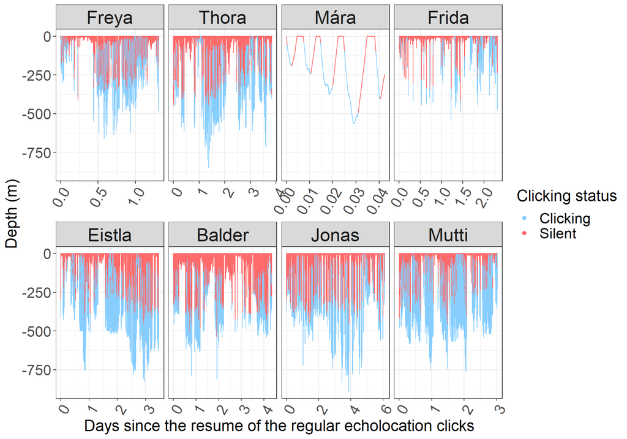

```r
ggplot(originaldata, aes(x=sst/(60*60*24), y=-Depth, colour=click_status))+
  geom_point(shape=".")+
  scale_color_manual(values = c("Silent"="indianred1","Clicking"="skyblue1"), name = "Clicking status") +
  facet_wrap(~whale,ncol=4, scales = "free_x") +
  xlab("Days since the resume of the regular echolocation clicks")+
  ylab("Depth (m)")+
  guides(colour = guide_legend(override.aes = list(size=2,shape=19)))+
  theme_bw()+
  theme(
        axis.title.x = element_text(size = 18),
        axis.text.x = element_text(size = 17,angle=60, hjust=1),
        axis.text.y = element_text(size = 17),
        axis.title.y = element_text(size = 18),
        legend.title = element_text(size=18),
        legend.text= element_text(size=17),
        plot.title = element_text(size=20),
        strip.text.x = element_text(size = 21))
```

```r
ggsave("Figures/Figure2.jpeg",dpi=600)
```

## 4.2 Other visualization

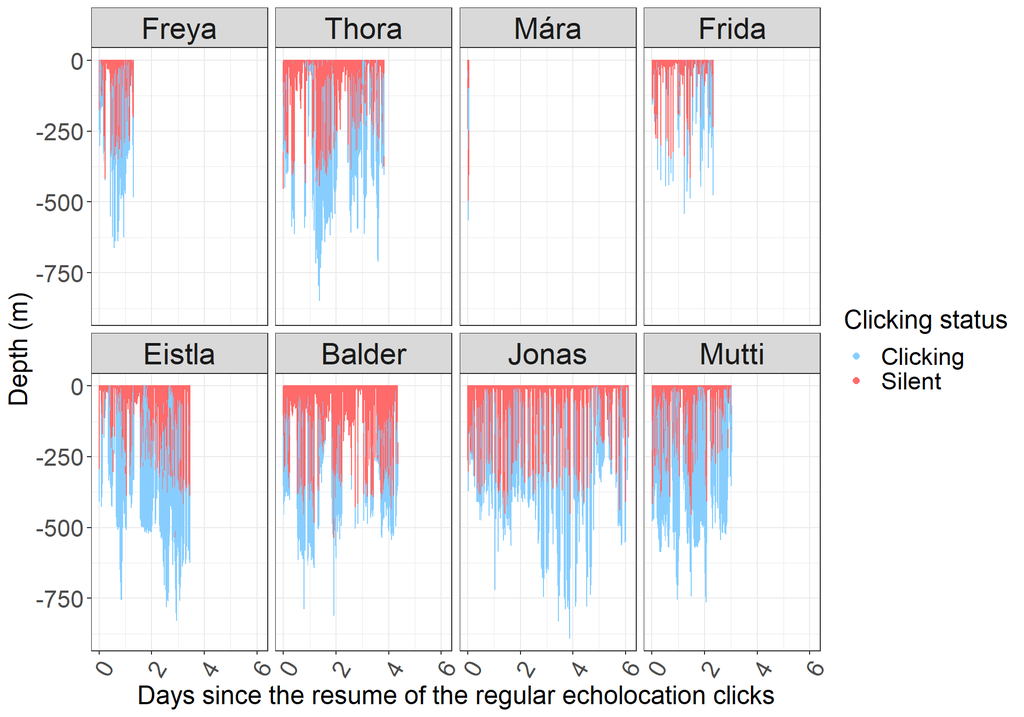

```r
ggplot(originaldata, aes(x=sst/(60*60*24), y=-Depth, colour=click_status))+
  geom_point(shape=".")+
  scale_color_manual(values = c("Silent"="indianred1","Clicking"="skyblue1"), name = "Clicking status") +
  facet_wrap(~whale,ncol=4) +
  xlab("Days since the resume of the regular echolocation clicks")+
  ylab("Depth (m)")+
  guides(colour = guide_legend(override.aes = list(size=2,shape=19)))+
  theme_bw()+
  theme(
        axis.title.x = element_text(size = 18),
        axis.text.x = element_text(size = 17,angle=60, hjust=1),
        axis.text.y = element_text(size = 17),
        axis.title.y = element_text(size = 18),
        legend.title = element_text(size=18),
        legend.text= element_text(size=17),
        plot.title = element_text(size=20),
        strip.text.x = element_text(size = 21))
```

# 5 Time until the start of the normal behaviour

```r
datasec<-originaldata%>%
  group_by(whale)%>%
  summarise(time=min(n)/(60*60*24))

data.frame(datasec)
```

```
##    whale      time
## 1  Freya 1.5325347
## 2  Thora 0.3920255
## 3   Mára 0.3742014
## 4  Frida 1.1239699
## 5 Eistla 0.7455208
## 6 Balder 2.6128588
## 7  Jonas 0.2767477
## 8  Mutti 1.2068981
```

The minimum time until the regular echolocation clicks were resumed was 0.277 days.

The maximum time until the regular echolocation clicks were resumed was 2.613 days.

The sd time until the regular echolocation clicks were resumed was 0.782 days.

The mean time until the regular echolocation clicks were resumed was 1.033 days.

The median time until the regular echolocation clicks were resumed was 0.935 days.

The cv time until the regular echolocation clicks were resumed was 0.757 days.

# 6 Total time of recording

```r
datasec_tot<-all_originaldata%>%
  group_by(whale)%>%
  summarise(time=n()/(60*60*24))

data.frame(datasec_tot)
```

```
##    whale      time
## 1  Freya 2.8426042
## 2  Thora 4.2253125
## 3   Mára 0.4166088
## 4  Frida 3.4445949
## 5 Eistla 4.2069444
## 6 Balder 8.7118287
## 7  Jonas 9.3406250
## 8  Mutti 4.2340856
```

The total recorded time for all the whales together was 37.423 days.

The minimum recorded time was 0.417 days.

The maximum recorded time was 9.341 days.

The sd recorded time was 2.969 days.

The mean recorded time was 4.678 days.

The median recorded time was 4.216 days.

The cv recorded time was 0.635 days.

# 7 Total time of recording after the regular echolocation clicks were resumed

```r
datasec_tot_r<-originaldata%>%
  group_by(whale)%>%
  summarise(time=n()/(60*60*24))

data.frame(datasec_tot_r)
```

```
##    whale       time
## 1  Freya 1.31008102
## 2  Thora 3.83329861
## 3   Mára 0.04241898
## 4  Frida 2.32063657
## 5 Eistla 3.46143519
## 6 Balder 4.34826389
## 7  Jonas 6.10075231
## 8  Mutti 3.02719907
```

The total time of recording after the regular echolocation clicks were resumed for all the whales together was 24.444 days.

The minimum time of recording after the regular echolocation clicks were resumed was 0.042 days.

The maximum time of recording after the regular echolocation clicks were resumed was 6.101 days.

The sd time of recording after the regular echolocation clicks were resumed was 1.866 days.

The mean time of recording after the regular echolocation clicks were resumed was 3.056 days.

The median time of recording after the regular echolocation clicks were resumed was 3.244 days.

The cv time of recording after the regular echolocation clicks were resumed was 0.611 days.

# 8 Proportion of time spent clicking

```r
prop_click_data<-originaldata%>%
  group_by(whale,click_status)%>%
  summarise(dur=n())
prop_click_data1<-prop_click_data%>%
  group_by(whale)%>%
  summarise(tot=sum(dur),value=ifelse(click_status=="Clicking",dur,0), clickings=sum(value),prop=clickings/tot)
prop_click_data11<- data.frame(whale=unique(prop_click_data1$whale),prop=unique(prop_click_data1$prop))

data.frame(whale=unique(prop_click_data1$whale),prop=unique(prop_click_data1$prop))
```

```
##    whale      prop
## 1  Freya 0.3280031
## 2  Thora 0.2763159
## 3   Mára 0.4245566
## 4  Frida 0.1890795
## 5 Eistla 0.3673312
## 6 Balder 0.2214405
## 7  Jonas 0.2839415
## 8  Mutti 0.4712139
```

The minimum proportion of time spent in a clicking period was 0.189

The maximum proportion of time spent in a clicking period was 0.471

The mean proportion of time spent in a clicking period was 0.32

The median proportion of time spent in a clicking period was 0.306

# 9 Number of samples analysed for clicks per second

```r
sample_n<-data.frame(sampledata%>%
  group_by(whale)%>%
  summarise(n_samples=n()))


sample_n
```

```
##    whale n_samples
## 1  Freya       200
## 2  Thora       150
## 3   Mára        10
## 4  Frida       149
## 5 Eistla       150
## 6 Balder       194
## 7  Jonas       200
## 8  Mutti       150
```

# 10 Table 1

```r
d1<-data.frame(`Narwhal ID`=datasec$whale,tf=round(datasec$time,2))# time until the resume of the regular echolocation clicks
d0<-data.frame(`Narwhal ID`=datasec_tot$whale,time=round(datasec_tot$time,2))# total time of the recording
d2<-data.frame(`Narwhal ID`=datasec_tot_r$whale,ta=round(datasec_tot_r$time,2))# total time of the recording after the resume of the regular echolocation clicks
d3<-data.frame(`Narwhal ID`=sample_n$whale,samples=sample_n$n_samples)# number of samples

data_s_y_f<-originaldata%>%
  group_by(Narwhal.ID=whale)%>%
  summarise(sex=unique(sex),year=unique(year),`acoustic sample rate (Hz)`=unique(frequency))


d<-full_join(d0,d1)
d<-full_join(d,d2)
d<-full_join(d,d3)
d<-full_join(d,data_s_y_f)
d[,c("Narwhal.ID", "sex", "year", "time", "tf", "ta", "samples", "acoustic sample rate (Hz)")]
```

```
##   Narwhal.ID    sex year time   tf   ta samples acoustic sample rate (Hz)
## 1      Freya Female 2013 2.84 1.53 1.31     200             25811 /154868
## 2      Thora Female 2014 4.23 0.39 3.83     150             25811 /154868
## 3       Mára Female 2014 0.42 0.37 0.04      10             25811 /154868
## 4      Frida Female 2015 3.44 1.12 2.32     149                     25811
## 5     Eistla Female 2016 4.21 0.75 3.46     150             25811 /154868
## 6     Balder   Male 2016 8.71 2.61 4.35     194                     25811
## 7      Jonas   Male 2019 9.34 0.28 6.10     200                     25811
## 8      Mutti Female 2019 4.23 1.21 3.03     150                     25811
```

# References

Blackwell, S.B., Tervo, O.M., Conrad, A.S., Sinding, M.H.S., Hansen, R.G., Ditlevsen, S. & Heide-Jørgensen, M.P. (2018). Spatial and temporal patterns of sound production in east greenland narwhals. *PLOS ONE*, **13**, e0198295. Retrieved from https://doi.org/10.1371/journal.pone.0198295